# Intro to Generalized Linear Models

December 2, 2021

## The General Linear Model

## Forget generalizing it, what is the general linear model?

- The general linear model is just the same basic linear regression model you know and love.

\[y = \alpha + \beta x_i + \epsilon\]

- But this way of writing regression equations hides a lot of assumptions

## Revealing the assumptions of your model

- To see what we’re hiding, let’s write this same model a different way

\[ \begin{aligned} y &\sim \text{Normal}(\mu_i, 0) \\ \mu_i &= \alpha + \beta \times x_i \end{aligned} \]

- \(\sim\) means “distributed”
- So, \(y\) is normally distributed with a mean of \(\mu\) and a standard deviation of 0
- We want to estimate the *average* outcome, which is why we “model” the mean
- To model the mean of our outcome, we use some linear equation: \(\mu = \alpha + \beta * x\)

## Revealing the assumptions of your model

So,

\[ \begin{aligned} y &\sim \text{Normal}(\mu_i, 0) \\ \mu_i &= \alpha + \beta \times x_i \end{aligned} \]

is the more complete way to express

\[y = \alpha + \beta x_i + \epsilon\]

because it tells us what likelihood and link (more on this later) functions we are using

## What are likelihood functions, again?

- Likelihood functions are essentially probability models of our data
- They describe the data generating process
- Ultimately the goal of statistics is to build a model that can make accurate predictions and describe data
- We do this by choosing likelihood functions that describe observed data

## Generalizing the General Linear Model

## What if the normal distribution doesn’t describe our data?

As an example, we’re going to use data on flights in the US:

```
## # A tibble: 6 × 23
##    year month   day dep_time sched_dep_time dep_delay arr_time sched_arr_time
##   <int> <int> <int>    <int>          <int>     <dbl>    <int>          <int>
## 1  2013     9     5      621            625        -4      745            800
## 2  2013     9    11     1832           1830         2     2200           2122
## 3  2013     7    31      628            630        -2      755            755
## 4  2013    10     4     1200           1200         0     1309           1315
## 5  2013     3     7     1022           1001        21     1149           1129
## 6  2013    12     8     1758           1800        -2     1942           1919
## # … with 15 more variables: arr_delay <dbl>, carrier <chr>, flight <int>,
## #   tailnum <chr>, origin <chr>, dest <chr>, air_time <dbl>, distance <dbl>,
## #   hour <dbl>, minute <dbl>, time_hour <dttm>, flight_delayed <chr>,
## #   delayed <dbl>, distance_c <dbl>, distance_2sd <dbl>
```

## What if the normal distribution doesn’t describe our data?

- Let’s try to see if the distance of a flight can predict whether the flight is delayed or not
- What probability model would describe flight delays? The normal distribution?

## Modeling Flight Delays

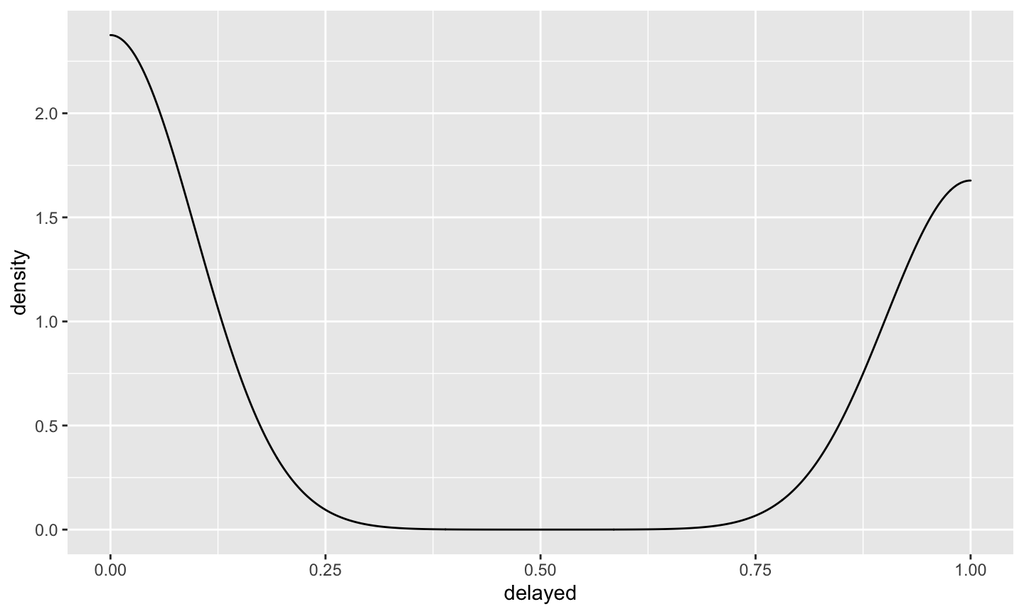

## Modeling Flight Delays

- The normal distribution doesn’t sound right to me
- The normal distribution describes a data generating process that produces continuous values from \(-\infty\) to \(\infty\)
- Let’s run with it anyway

```r
normal.fit <- glm(delayed ~ distance_2sd,
                  family = gaussian(),
                  data = flights)
```

## Modeling Flight Delays

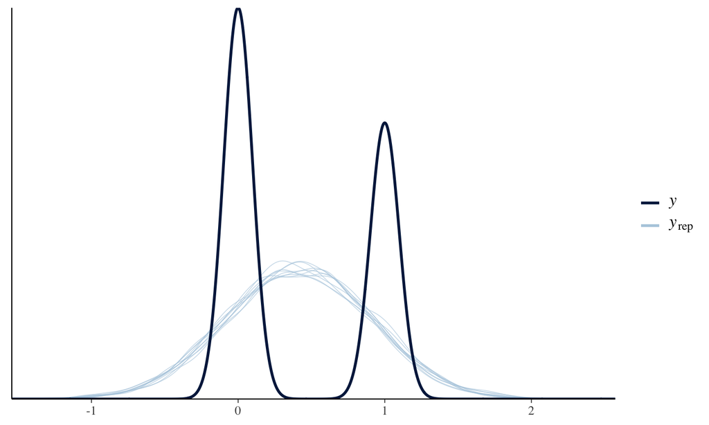

## Modeling Flight Delays

- The normal distribution doesn’t model the data very well
- We need a likelihood function that describes a data generating process that produces discrete values of either 0 or 1
- The binomial and Bernoulli distributions both describe that process

## Modeling Flight Delays

\[ \begin{aligned} y_i &\sim \text{Binomial}(1, p_i) \\ \text{logit}(p_i) &= \alpha + \beta \times x \end{aligned} \]

- What is our likelihood function?
- What is our link function?

## Wait, what is a link function?

- Link functions are used to map the range of a linear equation to the range of the outcome variable
- The logit link function restricts the range of the linear equation to be either 0 or 1
- The log link function restricts the range of the linear equation to be positive, continuous, and greater than 0

## Connecting the Dots

- Our models always use the same linear structure (\(\mu_i = \alpha + \beta x_i\))
- But, we can use any likelihood and link function that we want
- With these two pieces, we can **generalize** our linear equation to model any type of data
- Hence, the **generalized linear model**
- It always has a linear equation, but it doesn’t always have a normal distribution!

## Modeling Flight Delays

- Let’s model flight delays with a more realistic likelihood function - the binomial

\[ \begin{aligned} y_i &\sim \text{Binomial}(1, p_i) \\ \text{logit}(p_i) &= \alpha + \beta \times x \end{aligned} \]

```r
binomial.fit <- glm(delayed ~ distance_2sd,
                    family = binomial(link = "logit"),
                    data = flights)
```

## Modeling Flight Delays

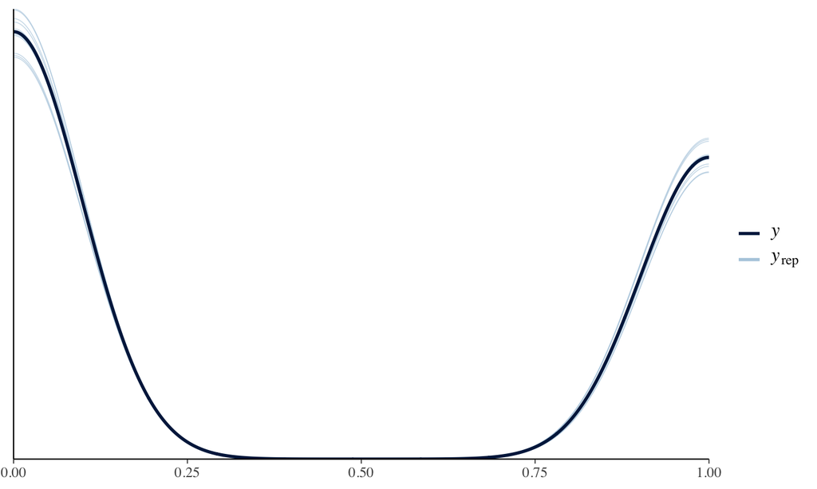

## How do we intrepret models with different likelihood and link functions?

- All you have to do is “undo” the link function
- Logit link function: \(\ln \left( \frac{P}{1 - P} \right)\)
- Inverse logit link function: \(\frac{1}{1 + \exp^{(P)}}\)
- Inverse logit link function in R: `plogis()`

## How do we intrepret models with different likelihood and link functions?

```
##  (Intercept) distance_2sd
##   -0.3529188    0.2009372
```

```r
plogis(coef(binomial.fit))
```

```
##  (Intercept) distance_2sd
##    0.4126748    0.5500660
```

A one unit increase in `distance_2sd` increases the relative probability of having a delayed flight by about 55%

## The Flexibility of GLMs

- GLMs can be used to model any type of data (just about)
- Pick a realistic likelihood function, then pick a link function

## Modeling Test

We want to model yard breaks as a function of the type of wool and the tension applied.

## Modeling Test

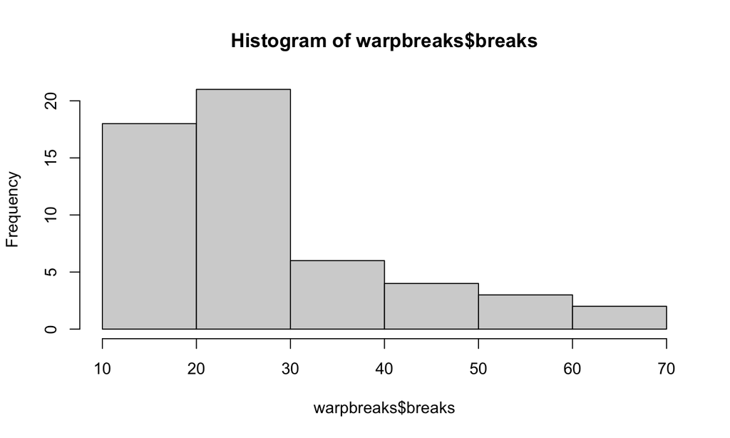

## Modeling Test

What kind of a distribution do we need?

- Continuous or discrete?
- Positive only, negative only, or all numbers?

## Modeling Test

- Poisson is discrete and positive only
- What kind of link function?

\[ \begin{aligned} y_i &\sim \text{Poisson}(\lambda_i) \\ \text{log}(\lambda_i) &= \alpha + \beta \times x \end{aligned} \]

```r
poisson.fit <- glm(breaks ~ wool + tension,
                   family = poisson(link = "log"),
                   data = warpbreaks)
```

## Modeling Test

What if we just used a normal likelihood function?

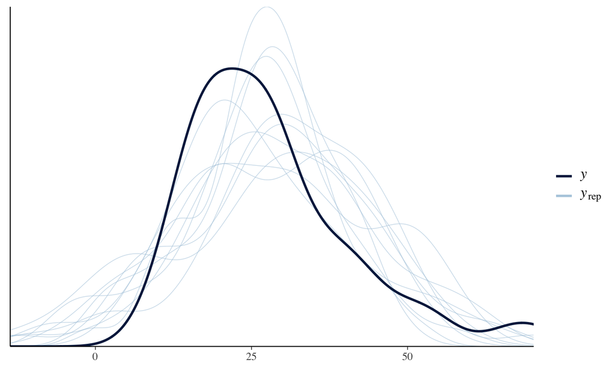

## Modeling Test

Now with a Poisson likelihood:

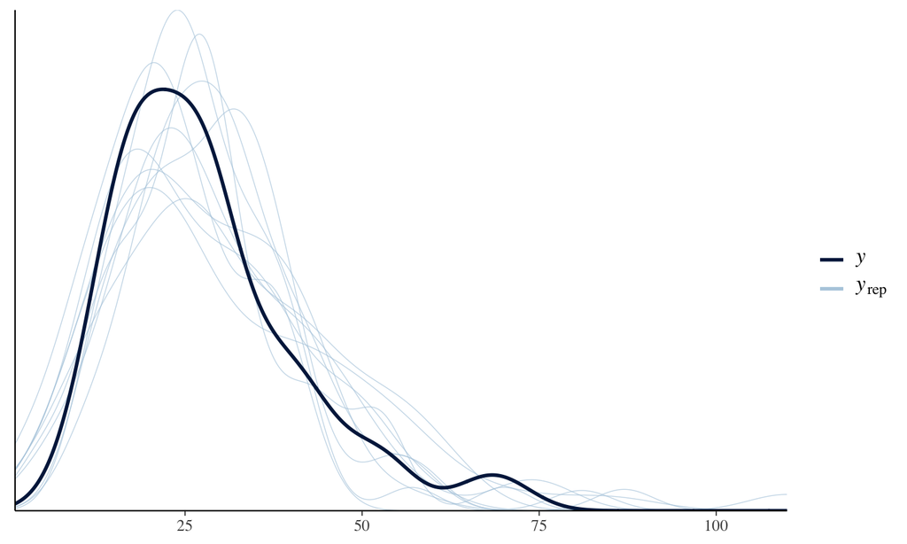

## Modeling Test

How would we interpret the coefficients from a Poisson regression?

```
## (Intercept)       woolB    tensionM    tensionH
##  40.1235380   0.8138425   0.7251908   0.5954198
```

- The coefficient was negative, so it decreases breaks
- Compared to wool A, the number of breaks for `woolB` is predicted to be \((1-0.813) * 100\) 18.7% lower.